# data_exploration

### Summer 2024 Data Science Project

### Group Members: Ethan, Avi, Jay, Mariia

## Introduction

The COVID-19 pandemic has had a profound impact on various aspects of life globally, with education being one of the most significantly affected sectors. As schools transitioned to remote learning and students faced unprecedented challenges, concerns about the quality of education and student performance have become increasingly prominent.

This study aims to investigate the correlation between students' COVID-19 positive status and their academic performance across different subjects. Specifically, we will analyze the effect of COVID-19 on writing, reading, and math scores, both at regular and state levels. Our primary questions are:

1. Does being COVID-19 positive affect students' scores in writing, reading, and math?
2. How do these effects vary between regular and state-level assessments?

Answering these questions is crucial for educators and policymakers to develop strategies to support students who have been affected by COVID-19 and to mitigate the pandemic's long-term negative impacts on education. Through rigorous data analysis, we aim to provide insights that can inform interventions and educational policies to help students recover and excel academically despite the challenges posed by the pandemic.

### Objectives

- To explore the relationship between COVID-19 positive status and academic scores.
- To determine if COVID-19 has a statistically significant impact on student performance.
- To provide visualizations that clearly depict the findings.
- To offer insights and recommendations based on the analysis.

## Data Curation

### Data Source

The dataset used in this study is obtained from Kaggle "Covid-19 Effect on Grade". This dataset includes information about students' COVID-19 status and their academic scores in writing, reading, and math.

### Data Description

The dataset contains the following columns:

- `covidpos`: Indicates whether the student tested positive for COVID-19 (1) or not (0).
- `writingscore`: The student's score in writing.
- `readingscore`: The student's score in reading.
- `mathscore`: The student's score in math.
- `writingscoreSL`: The student's state-level score in writing.
- `readingscoreSL`: The student's state-level score in reading.
- `mathscoreSL`: The student's state-level score in math.

### Data Transformation

To prepare the data for analysis, we load it into a Pandas DataFrame and perform necessary cleaning and preprocessing steps. This involves handling missing values, checking for data consistency, and ensuring the data is in a suitable format for analysis.

#### Loading and Inspecting the Dataset

```python
import pandas as pd
import numpy as np
from scipy.stats import chi2_contingency, zscore, ttest_ind
from sklearn.model_selection import train_test_split
from sklearn.linear_model import LinearRegression
from sklearn.ensemble import RandomForestRegressor
from sklearn.metrics import mean_squared_error, r2_score
from sklearn.linear_model import ElasticNet
import matplotlib.pyplot as plt
import seaborn as sns

# dataset
df = pd.read_excel('COVID-19-Constructed-Dataset.xlsx')
df.head()
```

|  | studentID | school | gradelevel | gender | covidpos | householdincome | freelunch | numcomputers | familysize | fathereduc | mothereduc | readingscore | writingscore | mathscore | readingscoreSL | writingscoreSL | mathscoreSL |
| --- | --- | --- | --- | --- | --- | --- | --- | --- | --- | --- | --- | --- | --- | --- | --- | --- | --- |
| 0 | 1 | 0 | 6 | 1 | 1 | 59065.136719 | 0 | 5 | 3 | 1 | 0 | 78.541451 | 83.166336 | 61.315819 | 64.989784 | 81.802025 | 61.637871 |
| 1 | 2 | 0 | 6 | 1 | 1 | 107480.085938 | 1 | 4 | 1 | 1 | 1 | 84.564743 | 82.970947 | 85.239334 | 82.694931 | 69.179840 | 72.869911 |
| 2 | 3 | 0 | 6 | 1 | 0 | 79800.843750 | 1 | 0 | 2 | 1 | 1 | 68.355804 | 83.814804 | 47.048065 | 78.966362 | 76.139626 | 80.808929 |
| 3 | 4 | 0 | 6 | 1 | 1 | 125976.164062 | 1 | 2 | 3 | 1 | 2 | 83.627121 | 92.576637 | 78.369659 | 82.449928 | 88.721786 | 70.429977 |
| 4 | 5 | 0 | 6 | 0 | 1 | 110744.156250 | 1 | 5 | 2 | 0 | 1 | 74.174385 | 67.225113 | 89.421799 | 80.836761 | 77.815231 | 83.921844 |

```python
# remove unnecessary columns
df.drop('studentID', axis=1, inplace=True)
df.drop('freelunch', axis=1, inplace=True)
df.drop('familysize', axis=1, inplace=True)
df.drop('fathereduc', axis=1, inplace=True)
df.drop('mothereduc', axis=1, inplace=True)
df.drop('school', axis=1, inplace=True)
df.drop('numcomputers', axis=1, inplace=True)

# handle missing values
df = df.dropna()
df.info()
```

```
<class 'pandas.core.frame.DataFrame'>
RangeIndex: 1400 entries, 0 to 1399
Data columns (total 10 columns):
 #   Column           Non-Null Count  Dtype
---  ------           --------------  -----
 0   gradelevel       1400 non-null   int64
 1   gender           1400 non-null   int64
 2   covidpos         1400 non-null   int64
 3   householdincome  1400 non-null   float64
 4   readingscore     1400 non-null   float64
 5   writingscore     1400 non-null   float64
 6   mathscore        1400 non-null   float64
 7   readingscoreSL   1400 non-null   float64
 8   writingscoreSL   1400 non-null   float64
 9   mathscoreSL      1400 non-null   float64
dtypes: float64(7), int64(3)
memory usage: 109.5 KB
```

### 3. Exploratory Data Analysis

## Exploratory Data Analysis

In this section, we perform exploratory data analysis (EDA) to understand the dataset better and identify any potential relationships between variables. EDA involves summarizing the main characteristics of the data, often with visual methods.

### Summary Statistics

First, we look at the summary statistics of the dataset to get an overall sense of the data distribution.

```python
# summary statistics
summary_statistics = df.describe()
print(summary_statistics)
```

```
        gradelevel       gender     covidpos  householdincome  readingscore  \
count  1400.000000  1400.000000  1400.000000      1400.000000   1400.000000
mean      9.000000     0.515714     0.331429     84290.222497     73.713863
std       2.000715     0.499932     0.470895     37763.724747     12.721292
min       6.000000     0.000000     0.000000         0.000000     27.025665
25%       7.000000     0.000000     0.000000     53210.644531     67.025629
50%       9.000000     1.000000     0.000000     85214.332031     75.101387
75%      11.000000     1.000000     1.000000    115975.230469     82.627476
max      12.000000     1.000000     1.000000    179296.531250    100.000000

       writingscore    mathscore  readingscoreSL  writingscoreSL  mathscoreSL
count   1400.000000  1400.000000     1400.000000     1400.000000  1400.000000
mean      76.520032    74.995766       70.933973       72.672313    71.773816
std       13.733770    12.875397       12.867588       12.997142    12.851248
min       26.059540    35.996704       22.885872       25.203316    36.798241
25%       67.463621    65.965166       63.710789       64.517370    62.299639
50%       78.256718    75.926838       72.836388       75.871681    72.069508
75%       87.229435    85.247686       80.452089       81.987513    81.922966
max      100.000000   100.000000      100.000000      100.000000   100.000000
```

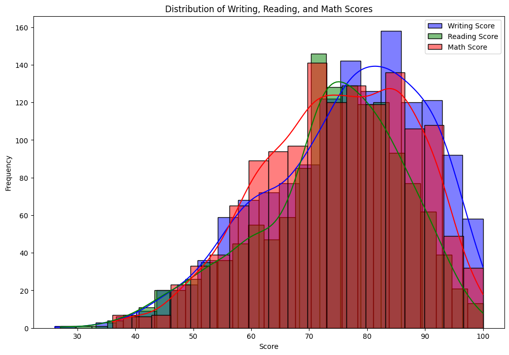

```python
plt.figure(figsize=(12, 8))
sns.histplot(df['writingscore'], kde=True, color='blue', label='Writing Score')
sns.histplot(df['readingscore'], kde=True, color='green', label='Reading Score')
sns.histplot(df['mathscore'], kde=True, color='red', label='Math Score')
plt.title('Distribution of Writing, Reading, and Math Scores')
plt.xlabel('Score')
plt.ylabel('Frequency')
plt.legend()
plt.show()
```

**Chi-Squared Test**

We perform chi-squared tests to check for associations between COVID-19 status and different scores. The chi-squared test helps us determine whether there is a significant relationship between categorical variables.

```python
# contingency tables
covid_writing = pd.crosstab(df['covidpos'], df['writingscore'])
covid_reading = pd.crosstab(df['covidpos'], df['readingscore'])
covid_math = pd.crosstab(df['covidpos'], df['mathscore'])
covid_writingSL = pd.crosstab(df['covidpos'], df['writingscoreSL'])
covid_readingSL = pd.crosstab(df['covidpos'], df['readingscoreSL'])
covid_mathSL = pd.crosstab(df['covidpos'], df['mathscoreSL'])

# Chi-squared tests
p_values = {
    'covid_writing': chi2_contingency(covid_writing).pvalue,
    'covid_reading': chi2_contingency(covid_reading).pvalue,
    'covid_math': chi2_contingency(covid_math).pvalue,
    'covid_writingSL': chi2_contingency(covid_writingSL).pvalue,
    'covid_readingSL': chi2_contingency(covid_readingSL).pvalue,
    'covid_mathSL': chi2_contingency(covid_mathSL).pvalue,
}

# p values
for test, p_value in p_values.items():
    print(f"p-value of {test} is {p_value:.3f}")
```

```
p-value of covid_writing is 0.457
p-value of covid_reading is 0.465
p-value of covid_math is 0.464
p-value of covid_writingSL is 0.450
p-value of covid_readingSL is 0.495
p-value of covid_mathSL is 0.465
```

**Correlation Analysis**

We analyze the correlation between COVID-19 status and various scores. Correlation coefficients indicate the strength and direction of a linear relationship between two variables.

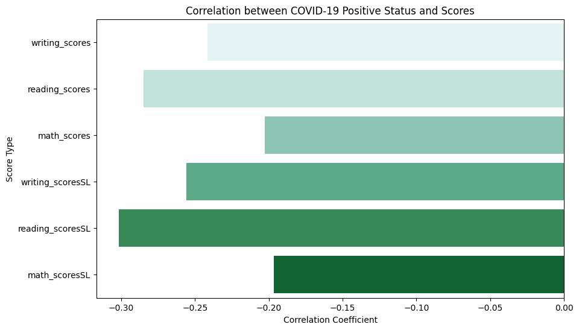

```python
# correlation analysis
correlations = {
    'writing_scores': df['covidpos'].corr(df['writingscore']),
    'reading_scores': df['covidpos'].corr(df['readingscore']),
    'math_scores': df['covidpos'].corr(df['mathscore']),
    'writing_scoresSL': df['covidpos'].corr(df['writingscoreSL']),
    'reading_scoresSL': df['covidpos'].corr(df['readingscoreSL']),
    'math_scoresSL': df['covidpos'].corr(df['mathscoreSL'])
}

# plotting
correlation_df = pd.DataFrame(list(correlations.items()), columns=['Score Type', 'Correlation'])

plt.figure(figsize=(10, 6))
sns.barplot(x='Correlation', y='Score Type', data=correlation_df, palette='BuGn', hue='Score Type')
plt.title('Correlation between COVID-19 Positive Status and Scores')
plt.xlabel('Correlation Coefficient')
plt.ylabel('Score Type')
plt.show()
```

Conclusion 1:

```python
#Z-Scores
scores = df[['mathscore', 'writingscore', 'readingscore', 'mathscoreSL', 'writingscoreSL', 'readingscoreSL']].apply(zscore)
print(scores.head())
```

```
   mathscore  writingscore  readingscore  mathscoreSL  writingscoreSL  \
0  -1.062867      0.484112      0.379624    -0.788995        0.702691
1   0.795877      0.469880      0.853275     0.085321       -0.268807
2  -2.171404      0.531346     -0.421339     0.703305        0.266870
3   0.262136      1.169551      0.779543    -0.104606        1.235288
4   1.120834     -0.677035      0.036214     0.945618        0.395838

   readingscoreSL
0       -0.462116
1        0.914325
2        0.624457
3        0.895278
4        0.769867
```

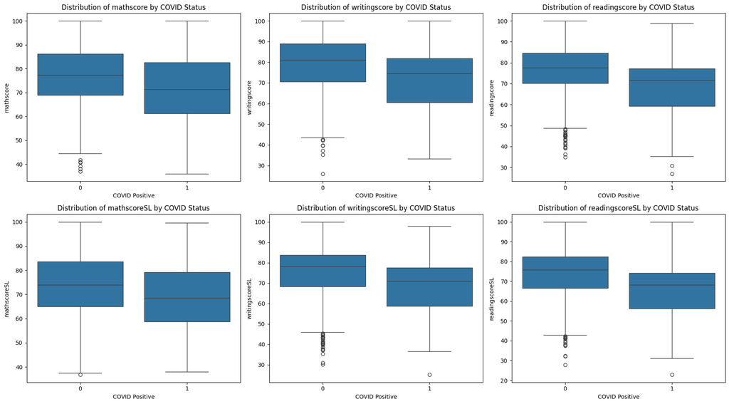

```python
# based on Z-scores, look at the outliers
fig, axs = plt.subplots(2, 3, figsize=(18, 10))

axs = axs.flatten()

for i, col in enumerate(scores):
    sns.boxplot(x='covidpos', y=col, data=df, ax=axs[i])
    axs[i].set_title(f'Distribution of {col} by COVID Status')
    axs[i].set_xlabel('COVID Positive')
    axs[i].set_ylabel(col)

plt.tight_layout()
plt.show()
```

Conclusion 2:

*The graphs indicate that both types of math scores are approximately normally distributed among students who tested positive for COVID. Additionally, all the scores appear to have outliers among students who tested negative for COVID. Both math scores and regular writing scores exhibit a few outliers, while the other scores show a significant number. Conversely, students who tested positive for COVID show either 1-2 outliers (in reading scores and State Level writing scores) or none at all (in math scores and regular writing scores).*

**T-Test Analysis**

Next, we perform t-tests to compare the mean state-level scores between COVID-positive and COVID-negative students.

```python
### State level
# mean scores for each group
mean_readingSL = df.groupby('covidpos')['readingscoreSL'].mean()
mean_writingSL = df.groupby('covidpos')['writingscoreSL'].mean()
mean_mathSL = df.groupby('covidpos')['mathscoreSL'].mean()

# two-sample t-tests
t_stat_readingSL, p_value_readingSL = ttest_ind(df[df['covidpos'] == 1]['readingscoreSL'], df[df['covidpos'] == 0]['readingscoreSL'])
t_stat_writingSL, p_value_writingSL = ttest_ind(df[df['covidpos'] == 1]['writingscoreSL'], df[df['covidpos'] == 0]['writingscoreSL'])
t_stat_mathSL, p_value_mathSL = ttest_ind(df[df['covidpos'] == 1]['mathscoreSL'], df[df['covidpos'] == 0]['mathscoreSL'])

t_test_df = pd.DataFrame({
    'Score Type': ['Reading Score (SL)', 'Writing Score (SL)', 'Math Score (SL)'],
    'T-Statistic': [t_stat_readingSL, t_stat_writingSL, t_stat_mathSL],
    'P-Value': [p_value_readingSL, p_value_writingSL, p_value_mathSL]
})
print("T-Test Results for State Level:")
print(t_test_df)




### Non-State level

# mean scores for each group
mean_reading = df.groupby('covidpos')['readingscore'].mean()
mean_writing = df.groupby('covidpos')['writingscore'].mean()
mean_math = df.groupby('covidpos')['mathscore'].mean()

# two-sample t-tests
t_stat_reading, p_value_reading = ttest_ind(df[df['covidpos'] == 1]['readingscore'], df[df['covidpos'] == 0]['readingscore'])
t_stat_writing, p_value_writing = ttest_ind(df[df['covidpos'] == 1]['writingscore'], df[df['covidpos'] == 0]['writingscore'])
t_stat_math, p_value_math = ttest_ind(df[df['covidpos'] == 1]['mathscore'], df[df['covidpos'] == 0]['mathscoreSL'])

t_test_df = pd.DataFrame({
    'Score Type': ['Reading Score', 'Writing Score', 'Math Score'],
    'T-Statistic': [t_stat_reading, t_stat_writing, t_stat_math],
    'P-Value': [p_value_reading, p_value_writing, p_value_math]
})
print("\n\nT-Test Results for non state level:")
print(t_test_df)
```

```
T-Test Results for State Level:
           Score Type  T-Statistic       P-Value
0  Reading Score (SL)   -11.825320  8.047835e-31
1  Writing Score (SL)    -9.898966  2.244505e-22
2     Math Score (SL)    -7.501287  1.118595e-13


T-Test Results for non state level:
      Score Type  T-Statistic       P-Value
0  Reading Score   -11.111976  1.503859e-27
1  Writing Score    -9.304861  5.009946e-20
2     Math Score    -3.135256  1.752792e-03
```

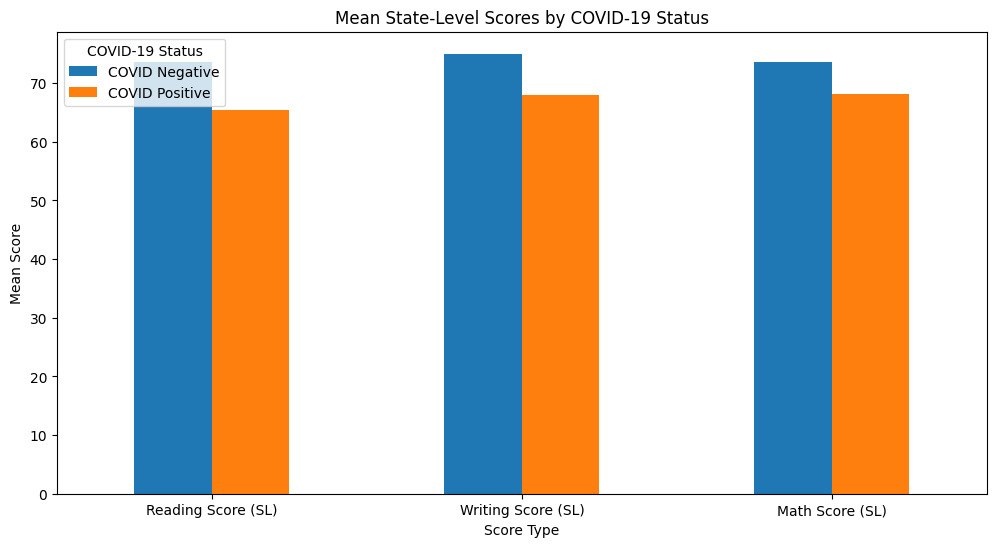

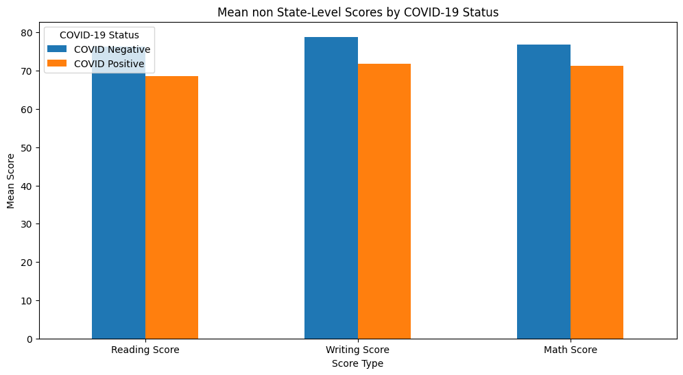

```python
# Plot the state level graph
mean_scores = pd.DataFrame({
    'COVID Negative': [mean_readingSL[0], mean_writingSL[0], mean_mathSL[0]],
    'COVID Positive': [mean_readingSL[1], mean_writingSL[1], mean_mathSL[1]]
}, index=['Reading Score (SL)', 'Writing Score (SL)', 'Math Score (SL)'])

mean_scores.plot(kind='bar', figsize=(12, 6))
plt.title('Mean State-Level Scores by COVID-19 Status')
plt.xlabel('Score Type')
plt.ylabel('Mean Score')
plt.xticks(rotation=0)
plt.legend(title='COVID-19 Status')
plt.show()

# Plot the non state level graph
mean_scores = pd.DataFrame({
    'COVID Negative': [mean_reading[0], mean_writing[0], mean_math[0]],
    'COVID Positive': [mean_reading[1], mean_writing[1], mean_math[1]]
}, index=['Reading Score', 'Writing Score', 'Math Score'])

mean_scores.plot(kind='bar', figsize=(12, 6))
plt.title('Mean non State-Level Scores by COVID-19 Status')
plt.xlabel('Score Type')
plt.ylabel('Mean Score')
plt.xticks(rotation=0)
plt.legend(title='COVID-19 Status')
plt.show()
```

Conclusion 3:

The t-test results indicate that being COVID-19 positive has a significant effect on both State and Non State Level scores. For state level reading (p = 8.05 x 10^−31), writing (p = 2.24 x 10^−22), and math (p = 1.12 x 10^−13) scores, while for non state level reading (p = 1.503859e-27), writing (p = 5.009946e-20), math( p = 1.752792e-03), all p-values are clearly significantly less than 0.05. Therefore, we reject the null hypothesis as we have shown that testing positive for COVID-19 negatively affects both State Level and Non State Level scores. The bar graph visually shows the score distributions between COVID-positive and COVID-negative groups.

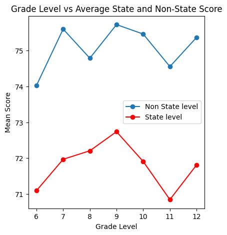

```python
# Group by grade level
grouped_df = df.groupby('gradelevel').agg({'mathscore': 'mean', 'writingscore': 'mean', 'readingscore': 'mean',
                                            'mathscoreSL': 'mean', 'writingscoreSL': 'mean', 'readingscoreSL': 'mean'}).reset_index()
# Calculate the overall mean of the three scores for each grade level
grouped_df['meanscore'] = grouped_df[['mathscore', 'writingscore', 'readingscore']].mean(axis=1) # NON STATE
grouped_df['meanscoreSL'] = grouped_df[['mathscoreSL', 'writingscoreSL', 'readingscoreSL']].mean(axis=1) # STATE


# Plot the correlation between grade level and average scores
plt.figure(figsize=(10, 5))

plt.subplot(1, 2, 1)
plt.plot(grouped_df['gradelevel'], grouped_df['meanscore'], label='Non State level', marker='o')
plt.plot(grouped_df['gradelevel'], grouped_df['meanscoreSL'], label='State level', marker='o', color='r')
plt.title('Grade Level vs Average State and Non-State Score')
plt.xlabel('Grade Level')
plt.ylabel('Mean Score')
plt.legend()
plt.show()
```

Now let's look at each of them separately, investigating on how the socioeconomic factors, particularly family income has influenced each of them

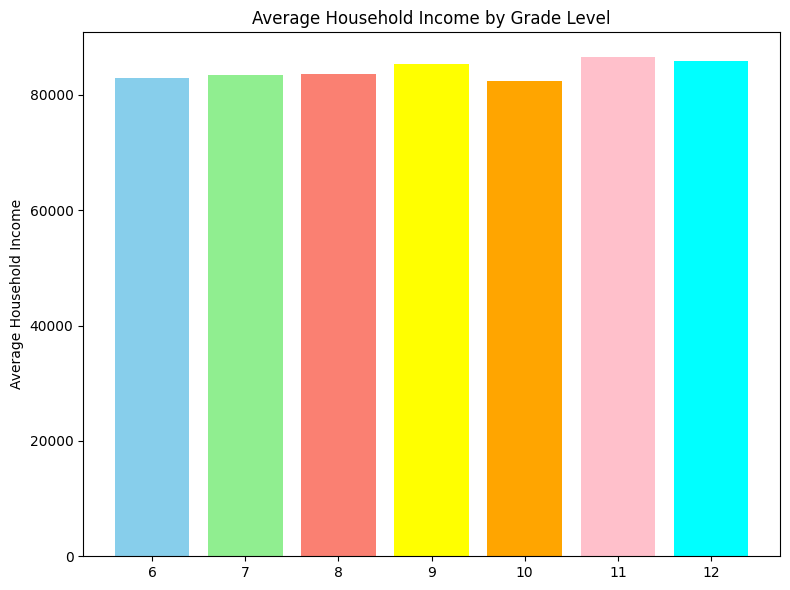

```python
grouped_df = df.groupby('gradelevel') ['householdincome'].mean().reset_index()
# Assign colors for each grade level
colors = {6: 'skyblue', 7: 'lightgreen', 8: 'salmon', 9: 'yellow', 10: 'orange',
          11: 'pink', 12: 'cyan'}
# Plotting
plt.figure(figsize=(8, 6))
plt.bar(grouped_df['gradelevel'], grouped_df['householdincome'], color=grouped_df['gradelevel'].map(colors))
plt.ylabel('Average Household Income' )
plt.title('Average Household Income by Grade Level')
plt.tight_layout()
plt.show()
```

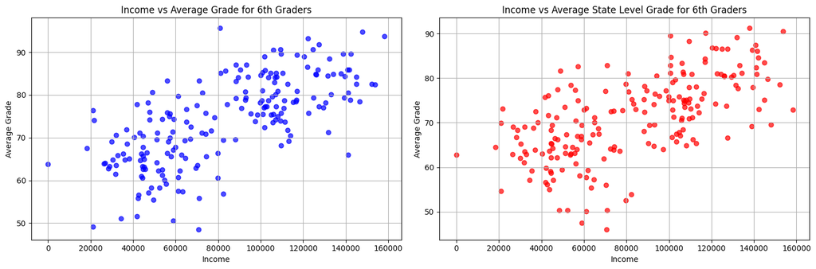

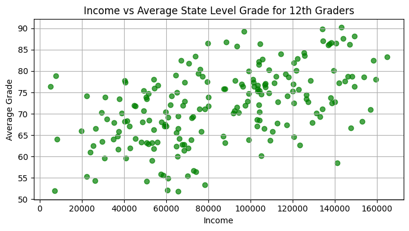

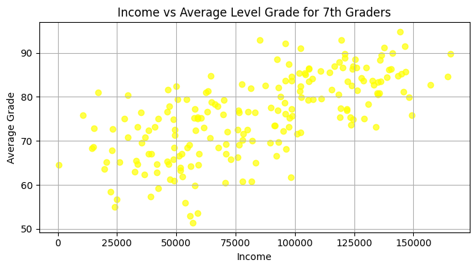

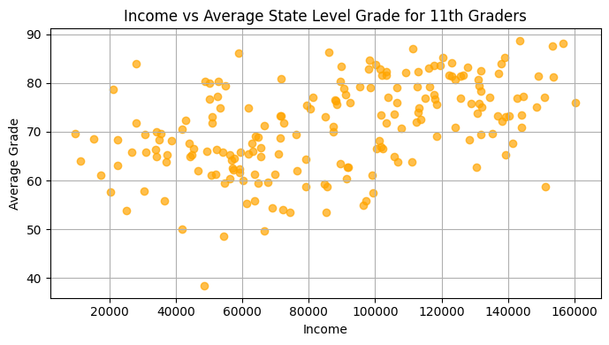

```python
from scipy.stats import pearsonr

# Filter for grades
grade_6_df = df[df['gradelevel'] == 6].copy()
grade_12_df = df[df['gradelevel'] == 12].copy()
grade_7_df = df[df['gradelevel'] == 7].copy()
grade_11_df = df[df['gradelevel'] == 11].copy()


grade_6_df['avg_score'] = grade_6_df[['mathscore', 'writingscore', 'readingscore']].mean(axis=1)
grade_6_df['avg_scoreSL'] = grade_6_df[['mathscoreSL', 'writingscoreSL', 'readingscoreSL']].mean(axis=1)

grade_12_df['avg_scoreSL'] = grade_12_df[['mathscoreSL', 'writingscoreSL', 'readingscoreSL']].mean(axis=1)
grade_7_df['avg_score'] = grade_7_df[['mathscore', 'writingscore', 'readingscore']].mean(axis=1)
grade_11_df['avg_scoreSL'] = grade_11_df[['mathscoreSL', 'writingscoreSL', 'readingscoreSL']].mean(axis=1)

# Calculate average score for 6th graders
grade_6_df['avg_score'] = grade_6_df[['mathscore', 'writingscore', 'readingscore']].mean(axis=1)
grade_6_df['avg_scoreSL'] = grade_6_df[['mathscoreSL', 'writingscoreSL', 'readingscoreSL']].mean(axis=1)



# Create figure and subplots
fig, (ax1, ax2) = plt.subplots(1, 2, figsize=(15, 5))

print()
# Plotting the first correlation
ax1.scatter(grade_6_df['householdincome'], grade_6_df['avg_score'], color='blue', alpha=0.7)
ax1.set_title('Income vs Average Grade for 6th Graders')
ax1.set_xlabel('Income')
ax1.set_ylabel('Average Grade')
ax1.grid(True)

# Plotting the second correlation
ax2.scatter(grade_6_df['householdincome'], grade_6_df['avg_scoreSL'], color='red', alpha=0.7)
ax2.set_title('Income vs Average State Level Grade for 6th Graders')
ax2.set_xlabel('Income')
ax2.set_ylabel('Average Grade')
ax2.grid(True)

# Adjust layout
plt.tight_layout()

# Display the plot
plt.show()

# Calculate average state level score for 12th graders
grade_12_df['avg_scoreSL'] = grade_12_df[['mathscoreSL', 'writingscoreSL', 'readingscoreSL']].mean(axis=1)


print()
# Plotting the correlation
plt.figure(figsize=(7, 4))
plt.scatter(grade_12_df['householdincome'], grade_12_df['avg_scoreSL'], color='green', alpha=0.7)
plt.title('Income vs Average State Level Grade for 12th Graders')
plt.xlabel('Income')
plt.ylabel('Average Grade')
plt.grid(True)
plt.tight_layout()
plt.show()


# Calculate average state level score for 7th graders
grade_7_df['avg_score'] = grade_7_df[['mathscore', 'writingscore', 'readingscore']].mean(axis=1)

print()
# Plotting the correlation
plt.figure(figsize=(7, 4))
plt.scatter(grade_7_df['householdincome'], grade_7_df['avg_score'], color='yellow', alpha=0.7)
plt.title('Income vs Average Level Grade for 7th Graders')
plt.xlabel('Income')
plt.ylabel('Average Grade')
plt.grid(True)
plt.tight_layout()
plt.show()

# Calculate average state level score for 12th graders
grade_11_df['avg_scoreSL'] = grade_11_df[['mathscoreSL', 'writingscoreSL', 'readingscoreSL']].mean(axis=1)

print()
# Plotting the correlation
plt.figure(figsize=(7, 4))
plt.scatter(grade_11_df['householdincome'], grade_11_df['avg_scoreSL'], color='orange', alpha=0.7)
plt.title('Income vs Average State Level Grade for 11th Graders')
plt.xlabel('Income')
plt.ylabel('Average Grade')
plt.grid(True)
plt.tight_layout()
plt.show()
```

```python
# Function to calculate average scores and correlation
def calculate_avg_and_correlation(df, grade, score_columns, scoreSL_columns):
    # Filter data for specific grade
    grade_df = df[df['gradelevel'] == grade].copy()

    # Calculate average scores
    grade_df.loc[:, 'avg_score'] = grade_df[score_columns].mean(axis=1)
    grade_df.loc[:, 'avg_scoreSL'] = grade_df[scoreSL_columns].mean(axis=1)

    # Calculate correlation on a state level
    correlation, p_value = pearsonr(grade_df['householdincome'], grade_df['avg_scoreSL'])

    print(f'\nCorrelation between household income and average score for {grade} graders on the state level: {correlation:.2f}')
    print(f'P-value: {p_value:.2e}')

    # Calculate correlation on a non state level
    correlation, p_value = pearsonr(grade_df['householdincome'], grade_df['avg_score'])

    print(f'Correlation between household income and average score for {grade} graders on the non state level: {correlation:.2f}')
    print(f'P-value: {p_value:.2e}\n')

    return grade_df

# Columns to use for calculating averages
score_columns = ['mathscore', 'writingscore', 'readingscore']
scoreSL_columns = ['mathscoreSL', 'writingscoreSL', 'readingscoreSL']

# Calculate and print correlation for each grade
grades = [6,7,8,9,10,11]
for grade in grades:
    calculate_avg_and_correlation(df, grade, score_columns, scoreSL_columns)
```

```
Correlation between household income and average score for 6 graders on the state level: 0.63
P-value: 3.83e-23
Correlation between household income and average score for 6 graders on the non state level: 0.69
P-value: 6.18e-30


Correlation between household income and average score for 7 graders on the state level: 0.54
P-value: 2.19e-16
Correlation between household income and average score for 7 graders on the non state level: 0.67
P-value: 3.75e-27


Correlation between household income and average score for 8 graders on the state level: 0.52
P-value: 4.42e-15
Correlation between household income and average score for 8 graders on the non state level: 0.66
P-value: 5.96e-26


Correlation between household income and average score for 9 graders on the state level: 0.59
P-value: 3.53e-20
Correlation between household income and average score for 9 graders on the non state level: 0.66
P-value: 1.81e-26


Correlation between household income and average score for 10 graders on the state level: 0.52
P-value: 2.63e-15
Correlation between household income and average score for 10 graders on the non state level: 0.65
P-value: 1.11e-25


Correlation between household income and average score for 11 graders on the state level: 0.48
P-value: 8.30e-13
Correlation between household income and average score for 11 graders on the non state level: 0.63
P-value: 2.35e-23
```

### Now we are going to look at the potential correlation between the Gender and the average scores

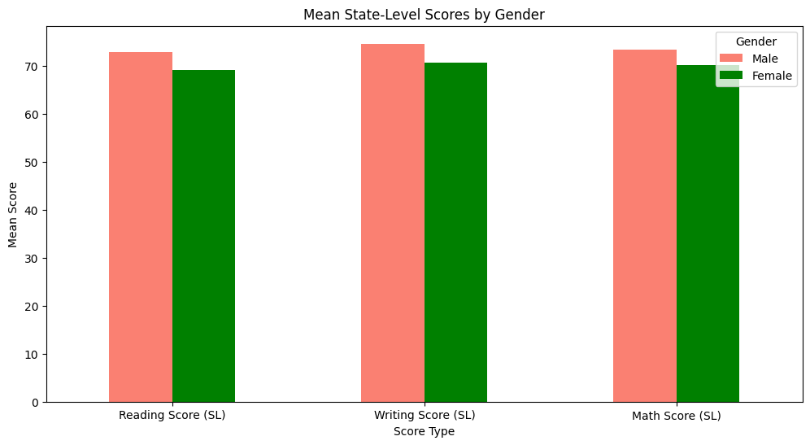

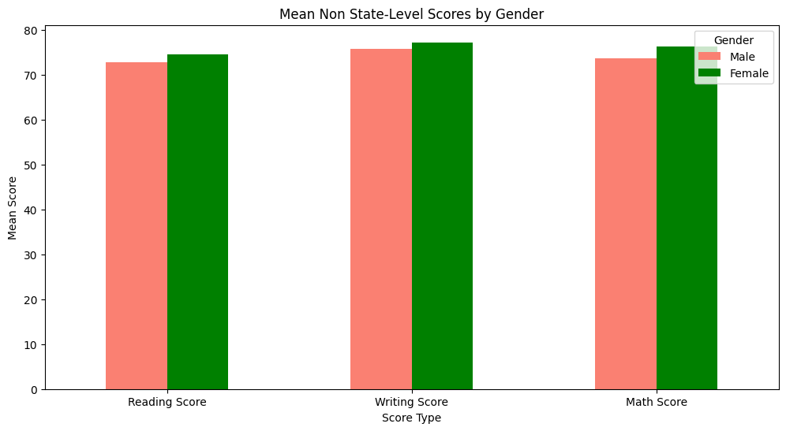

```python
mean_reading = df.groupby('gender')['readingscore'].mean()
mean_writing = df.groupby('gender')['writingscore'].mean()
mean_math = df.groupby('gender')['mathscore'].mean()

# Mean scores for each group
mean_readingSL = df.groupby('gender')['readingscoreSL'].mean()
mean_writingSL = df.groupby('gender')['writingscoreSL'].mean()
mean_mathSL = df.groupby('gender')['mathscoreSL'].mean()

# Plot the state-level graph
mean_scores_SL = pd.DataFrame({
    'Male': [mean_readingSL[1], mean_writingSL[1], mean_mathSL[1]],
    'Female': [mean_readingSL[0], mean_writingSL[0], mean_mathSL[0]]
}, index=['Reading Score (SL)', 'Writing Score (SL)', 'Math Score (SL)'])

ax = mean_scores_SL.plot(kind='bar', figsize=(12, 6), color=['salmon', 'green'])
plt.title('Mean State-Level Scores by Gender')
plt.xlabel('Score Type')
plt.ylabel('Mean Score')
plt.xticks(rotation=0)
plt.legend(title='Gender')
plt.show()

# Plot the non-state-level graph
mean_scores_non_SL = pd.DataFrame({
    'Male': [mean_reading[1], mean_writing[1], mean_math[1]],
    'Female': [mean_reading[0], mean_writing[0], mean_math[0]]
}, index=['Reading Score', 'Writing Score', 'Math Score'])

ax = mean_scores_non_SL.plot(kind='bar', figsize=(12, 6), color=['salmon', 'green'])
plt.title('Mean Non State-Level Scores by Gender')
plt.xlabel('Score Type')
plt.ylabel('Mean Score')
plt.xticks(rotation=0)
plt.legend(title='Gender')
plt.show()
```

### Overall, on average the boys have performed better on all types of tests on state level, while the girls bettered them at all tests on the non state level. We can conclude that gender indeed had somewhat affected the student performance overall

## Primary Analysis

### Model: RandomForest Analysis

We chose to perform a RandomForest analysis to find the correlation between COVID-19 positive and negative students. RandomForest is probably best here since the complexity added with the RandomForest might be beneficial in helping the model explain the dataset. We will be analyzing their academic performance in writing, reading, and math so that we can predict academic scores based on COVID-19 status.

```python
# define features and targets
df['income_grade'] = df['householdincome'] * df['gradelevel']
df['income_gender'] = df['householdincome'] * df['gender']

X = df[['covidpos', 'householdincome', 'gradelevel', 'gender', 'income_grade', 'income_gender']]
y_writing = df['writingscore']
y_reading = df['readingscore']
y_math = df['mathscore']

# splitting into training and testing
X_train_writing, X_test_writing, y_train_writing, y_test_writing = train_test_split(X, y_writing, test_size=0.2, random_state=42)
X_train_reading, X_test_reading, y_train_reading, y_test_reading = train_test_split(X, y_reading, test_size=0.2, random_state=42)
X_train_math, X_test_math, y_train_math, y_test_math = train_test_split(X, y_math, test_size=0.2, random_state=42)
```

### Training and evaluation

Now that we split the data, we also determined that a 80/20 is the optimal proportion (20% data is used for test set and 80% for training set) to use for the test and training set.

We can move on to training our RandomForest model for each of the academic scores using the training data. We're going to initialize the RandomForest model and then fit the model to the training data. Then we can start making predictions.

```python
# training
rf_model_writing = RandomForestRegressor(random_state=42).fit(X_train_writing, y_train_writing)
rf_model_reading = RandomForestRegressor(random_state=42).fit(X_train_reading, y_train_reading)
rf_model_math = RandomForestRegressor(random_state=42).fit(X_train_math, y_train_math)

# predicting
y_pred_writing_rf = rf_model_writing.predict(X_test_writing)
y_pred_reading_rf = rf_model_reading.predict(X_test_reading)
y_pred_math_rf = rf_model_math.predict(X_test_math)
```

After training and predicting our RandomForest model, we have to make sure that the models explain the data well. To measure their performance, we can evaluate the models using Mean Squared Error and R squared to assess performance.

```python
# evaluations
mse_writing_rf = mean_squared_error(y_test_writing, y_pred_writing_rf)
mse_reading_rf = mean_squared_error(y_test_reading, y_pred_reading_rf)
mse_math_rf = mean_squared_error(y_test_math, y_pred_math_rf)

r2_writing_rf = r2_score(y_test_writing, y_pred_writing_rf)
r2_reading_rf = r2_score(y_test_reading, y_pred_reading_rf)
r2_math_rf = r2_score(y_test_math, y_pred_math_rf)

print(f"RF writing: {mse_writing_rf}, R2: {r2_writing_rf}")
print(f"RF reading: {mse_reading_rf}, R2: {r2_reading_rf}")
print(f"RF math: {mse_math_rf}, R2: {r2_math_rf}")
```

```
RF writing: 175.02059185337438, R2: 0.09656794765443166
RF reading: 142.38983657718018, R2: 0.2022087526147367
RF math: 159.854550592058, R2: 0.04970296968695043
```

The writing scores show that the predicted scores are don't align with the actual scores. The R2 value of 0.09 means that the model explained 9% of the variance in writing scores. This indicates that there are prediction errors that cause noticeable spread and low R2 value.

Similarly, math has a R2 score of 0.04, the lowest of the 3 subjects. Math seems to exhibit more spread, with predictions deviating more from ideal compared to reading and writing. The model was only able to explain about 4% of the variance which is jaw-droppingly low.

Weirdly, the reading has a R2 values of 0.202 which means RandomForest was able to explain 20% of the data. This, however, is still not the best with its modest R2 score.

Given the relatively poor performance from our RandomForest models, we can improve our predictions by using linear regression models. This learning menthod is best when handling linear relationships between variables so that they're less prone to overfitting (which we think would perform better).

Implmenting Linear Regression is similar to RandomForest. All we need to do is train and fit the model to start predicting score changes. We can then evaluate LR's performance and compare it with RF to see if it truly is better with our dataset.

```python
# training models
model_writing = LinearRegression().fit(X_train_writing, y_train_writing)
model_reading = LinearRegression().fit(X_train_reading, y_train_reading)
model_math = LinearRegression().fit(X_train_math, y_train_math)

# score predicting
y_pred_writing = model_writing.predict(X_test_writing)
y_pred_reading = model_reading.predict(X_test_reading)
y_pred_math = model_math.predict(X_test_math)
```

```python
# model performance
mse_writing = mean_squared_error(y_test_writing, y_pred_writing)
mse_reading = mean_squared_error(y_test_reading, y_pred_reading)
mse_math = mean_squared_error(y_test_math, y_pred_math)

r2_writing = r2_score(y_test_writing, y_pred_writing)
r2_reading = r2_score(y_test_reading, y_pred_reading)
r2_math = r2_score(y_test_math, y_pred_math)

print(f"Writing: MSE = {mse_writing}, R2 = {r2_writing}")
print(f"Reading: MSE = {mse_reading}, R2 = {r2_reading}")
print(f"Math: MSE = {mse_math}, R2 = {r2_math}")
```

```
Writing: MSE = 137.29831207137443, R2 = 0.29128513082540675
Reading: MSE = 126.10340360060967, R2 = 0.2934594625823117
Math: MSE = 130.2991957487123, R2 = 0.22540247798030544
```

As we can see, both writing and reading R2 values are at 0.291 and 0.293 respectively. Even though these values are modest at best, it does significantly better than RF at explaining the variance in the data. Almost 30%! A big jump from what was once a single digit percentage. Even math was able to acheive a R2 score of 0.22 from its previous value of 0.04.

This might be the best we can do in terms of modeling but we're going to try one more just to see if there is a better method to explain the variance. ElasticNet combines the properties of both Lasso and Ridge regression and can be very effective when there are multiple features with potential collinearity.

```python
# training
en_model_writing = ElasticNet(random_state=42).fit(X_train_writing, y_train_writing)
en_model_reading = ElasticNet(random_state=42).fit(X_train_reading, y_train_reading)
en_model_math = ElasticNet(random_state=42).fit(X_train_math, y_train_math)

# predicting
y_pred_writing_en = en_model_writing.predict(X_test_writing)
y_pred_reading_en = en_model_reading.predict(X_test_reading)
y_pred_math_en = en_model_math.predict(X_test_math)

#evaluations
mse_writing_en = mean_squared_error(y_test_writing, y_pred_writing_en)
mse_reading_en = mean_squared_error(y_test_reading, y_pred_reading_en)
mse_math_en = mean_squared_error(y_test_math, y_pred_math_en)

r2_writing_en = r2_score(y_test_writing, y_pred_writing_en)
r2_reading_en = r2_score(y_test_reading, y_pred_reading_en)
r2_math_en = r2_score(y_test_math, y_pred_math_en)

print(f"ElasticNet writing: {mse_writing_en}, R2: {r2_writing_en}")
print(f"ElasticNet reading: MSE = {mse_reading_en}, R2 = {r2_reading_en}")
print(f"ElasticNet math: MSE = {mse_math_en}, R2 = {r2_math_en}")
```

```
ElasticNet writing: 135.2917896254494, R2: 0.30164252175982975
ElasticNet reading: MSE = 129.8182170753002, R2 = 0.2726458585567847
ElasticNet math: MSE = 132.10786933183522, R2 = 0.21465034656783388
```

Wow, well that's unfortunate. We were able to improve the writing R2 score by about 0.01... but both reading and math dropped. Low R2 scores in Linear Regression, Random Forest, and Elastic Net models can happen for a bunch of reasons. It could be that we're using irrelevant or missing features, the data might be noisy or have outliers, or there could be measurement errors messing things up. Sometimes the models are either too simple (underfitting) or too complex (overfitting). We might also be dealing with too little or imbalanced data, and features that are highly correlated (multicollinearity) can also cause trouble. All these factors can throw off the model's ability to accurately explain the variance in the target variable.

To address these issues, it might be better to use more complex models like a neural network.

### Visualizations

Let's visualize the results of our regression models to better understand the relationships between COVID-19 status and student scores.

### RandomForest plots

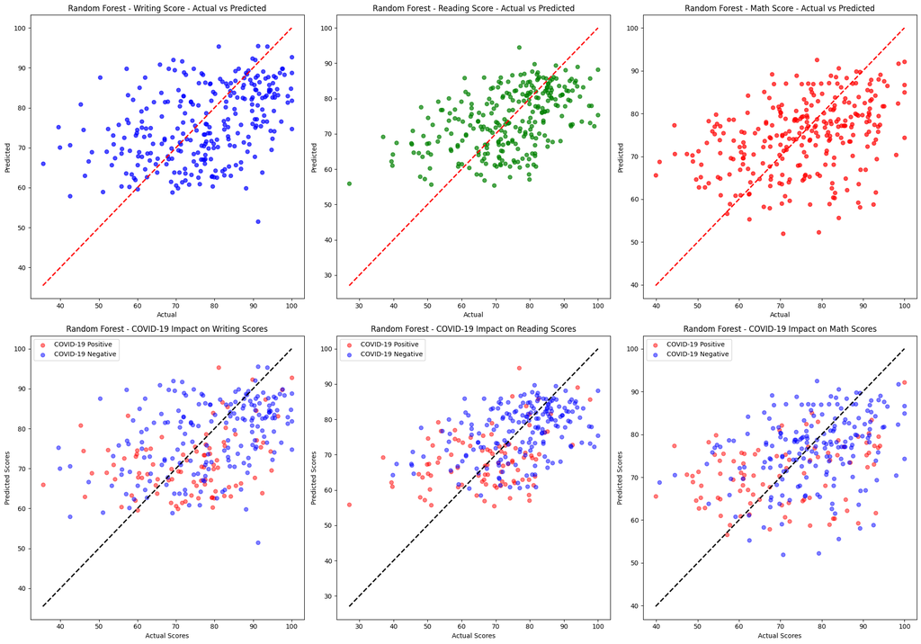

```python
plt.figure(figsize=(20, 14))

plt.subplot(2, 3, 1)
plt.scatter(y_test_writing, y_pred_writing_rf, alpha=0.7, color='blue')
plt.plot([y_test_writing.min(), y_test_writing.max()], [y_test_writing.min(), y_test_writing.max()], '--r', linewidth=2)
plt.title('Random Forest - Writing Score - Actual vs Predicted')
plt.xlabel('Actual')
plt.ylabel('Predicted')

plt.subplot(2, 3, 2)
plt.scatter(y_test_reading, y_pred_reading_rf, alpha=0.7, color='green')
plt.plot([y_test_reading.min(), y_test_reading.max()], [y_test_reading.min(), y_test_reading.max()], '--r', linewidth=2)
plt.title('Random Forest - Reading Score - Actual vs Predicted')
plt.xlabel('Actual')
plt.ylabel('Predicted')

plt.subplot(2, 3, 3)
plt.scatter(y_test_math, y_pred_math_rf, alpha=0.7, color='red')
plt.plot([y_test_math.min(), y_test_math.max()], [y_test_math.min(), y_test_math.max()], '--r', linewidth=2)
plt.title('Random Forest - Math Score - Actual vs Predicted')
plt.xlabel('Actual')
plt.ylabel('Predicted')

plt.subplot(2, 3, 4)
covid_pos_writing = X_test_writing['covidpos'] == 1
covid_neg_writing = X_test_writing['covidpos'] == 0
plt.scatter(y_test_writing[covid_pos_writing], y_pred_writing_rf[covid_pos_writing], color='red', alpha=0.5, label='COVID-19 Positive')
plt.scatter(y_test_writing[covid_neg_writing], y_pred_writing_rf[covid_neg_writing], color='blue', alpha=0.5, label='COVID-19 Negative')
plt.plot([y_test_writing.min(), y_test_writing.max()], [y_test_writing.min(), y_test_writing.max()], 'k--', lw=2)
plt.xlabel('Actual Scores')
plt.ylabel('Predicted Scores')
plt.title('Random Forest - COVID-19 Impact on Writing Scores')
plt.legend()

plt.subplot(2, 3, 5)
covid_pos_reading = X_test_reading['covidpos'] == 1
covid_neg_reading = X_test_reading['covidpos'] == 0
plt.scatter(y_test_reading[covid_pos_reading], y_pred_reading_rf[covid_pos_reading], color='red', alpha=0.5, label='COVID-19 Positive')
plt.scatter(y_test_reading[covid_neg_reading], y_pred_reading_rf[covid_neg_reading], color='blue', alpha=0.5, label='COVID-19 Negative')
plt.plot([y_test_reading.min(), y_test_reading.max()], [y_test_reading.min(), y_test_reading.max()], 'k--', lw=2)
plt.xlabel('Actual Scores')
plt.ylabel('Predicted Scores')
plt.title('Random Forest - COVID-19 Impact on Reading Scores')
plt.legend()

plt.subplot(2, 3, 6)
covid_pos_math = X_test_math['covidpos'] == 1
covid_neg_math = X_test_math['covidpos'] == 0
plt.scatter(y_test_math[covid_pos_math], y_pred_math_rf[covid_pos_math], color='red', alpha=0.5, label='COVID-19 Positive')
plt.scatter(y_test_math[covid_neg_math], y_pred_math_rf[covid_neg_math], color='blue', alpha=0.5, label='COVID-19 Negative')
plt.plot([y_test_math.min(), y_test_math.max()], [y_test_math.min(), y_test_math.max()], 'k--', lw=2)
plt.xlabel('Actual Scores')
plt.ylabel('Predicted Scores')
plt.title('Random Forest - COVID-19 Impact on Math Scores')
plt.legend()

plt.tight_layout()
plt.show()
```

### linear regression plots

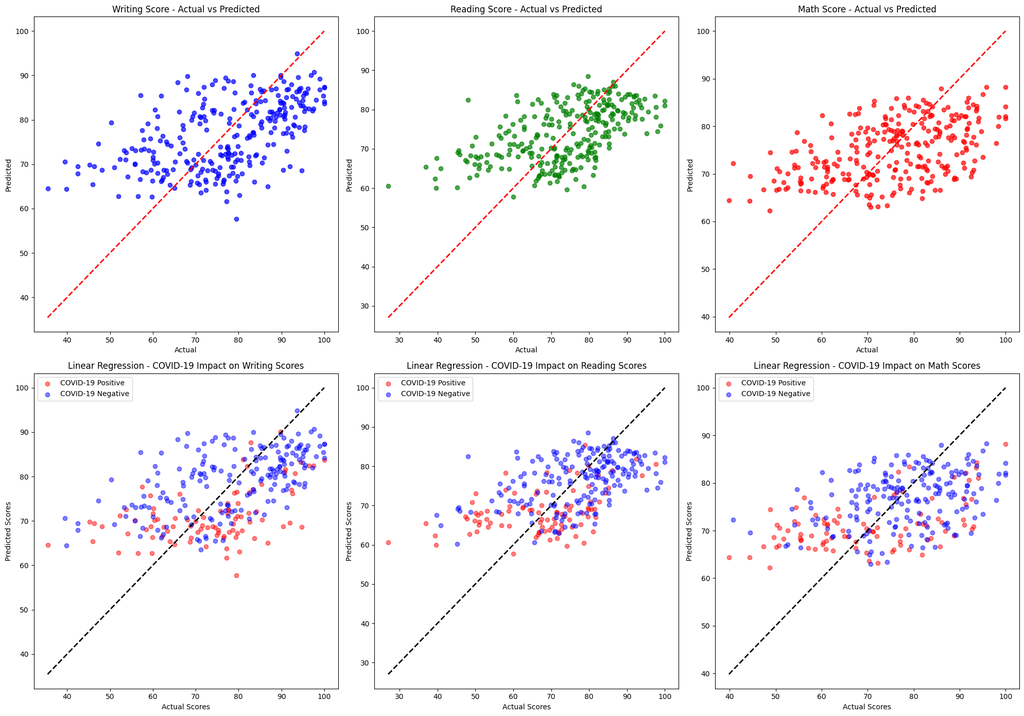

```python
plt.figure(figsize=(20, 14))

plt.subplot(2, 3, 1)
plt.scatter(y_test_writing, y_pred_writing, alpha=0.7, color='blue')
plt.plot([y_test_writing.min(), y_test_writing.max()], [y_test_writing.min(), y_test_writing.max()], '--r', linewidth=2)
plt.title('Writing Score - Actual vs Predicted')
plt.xlabel('Actual')
plt.ylabel('Predicted')

plt.subplot(2, 3, 2)
plt.scatter(y_test_reading, y_pred_reading, alpha=0.7, color='green')
plt.plot([y_test_reading.min(), y_test_reading.max()], [y_test_reading.min(), y_test_reading.max()], '--r', linewidth=2)
plt.title('Reading Score - Actual vs Predicted')
plt.xlabel('Actual')
plt.ylabel('Predicted')

plt.subplot(2, 3, 3)
plt.scatter(y_test_math, y_pred_math, alpha=0.7, color='red')
plt.plot([y_test_math.min(), y_test_math.max()], [y_test_math.min(), y_test_math.max()], '--r', linewidth=2)
plt.title('Math Score - Actual vs Predicted')
plt.xlabel('Actual')
plt.ylabel('Predicted')

plt.subplot(2, 3, 4)
covid_pos_writing = X_test_writing['covidpos'] == 1
covid_neg_writing = X_test_writing['covidpos'] == 0
plt.scatter(y_test_writing[covid_pos_writing], y_pred_writing[covid_pos_writing], color='red', alpha=0.5, label='COVID-19 Positive')
plt.scatter(y_test_writing[covid_neg_writing], y_pred_writing[covid_neg_writing], color='blue', alpha=0.5, label='COVID-19 Negative')
plt.plot([y_test_writing.min(), y_test_writing.max()], [y_test_writing.min(), y_test_writing.max()], 'k--', lw=2)
plt.xlabel('Actual Scores')
plt.ylabel('Predicted Scores')
plt.title('Linear Regression - COVID-19 Impact on Writing Scores')
plt.legend()

plt.subplot(2, 3, 5)
covid_pos_reading = X_test_reading['covidpos'] == 1
covid_neg_reading = X_test_reading['covidpos'] == 0
plt.scatter(y_test_reading[covid_pos_reading], y_pred_reading[covid_pos_reading], color='red', alpha=0.5, label='COVID-19 Positive')
plt.scatter(y_test_reading[covid_neg_reading], y_pred_reading[covid_neg_reading], color='blue', alpha=0.5, label='COVID-19 Negative')
plt.plot([y_test_reading.min(), y_test_reading.max()], [y_test_reading.min(), y_test_reading.max()], 'k--', lw=2)
plt.xlabel('Actual Scores')
plt.ylabel('Predicted Scores')
plt.title('Linear Regression - COVID-19 Impact on Reading Scores')
plt.legend()

plt.subplot(2, 3, 6)
covid_pos_math = X_test_math['covidpos'] == 1
covid_neg_math = X_test_math['covidpos'] == 0
plt.scatter(y_test_math[covid_pos_math], y_pred_math[covid_pos_math], color='red', alpha=0.5, label='COVID-19 Positive')
plt.scatter(y_test_math[covid_neg_math], y_pred_math[covid_neg_math], color='blue', alpha=0.5, label='COVID-19 Negative')
plt.plot([y_test_math.min(), y_test_math.max()], [y_test_math.min(), y_test_math.max()], 'k--', lw=2)
plt.xlabel('Actual Scores')
plt.ylabel('Predicted Scores')
plt.title('Linear Regression - COVID-19 Impact on Math Scores')
plt.legend()

plt.tight_layout()
plt.show()
```

### ElasticNet plots

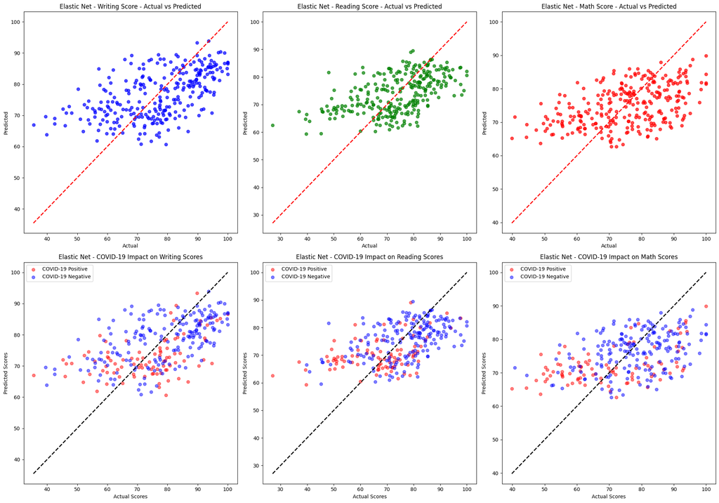

```python
plt.figure(figsize=(20, 14))

plt.subplot(2, 3, 1)
plt.scatter(y_test_writing, y_pred_writing_en, alpha=0.7, color='blue')
plt.plot([y_test_writing.min(), y_test_writing.max()], [y_test_writing.min(), y_test_writing.max()], '--r', linewidth=2)
plt.title('Elastic Net - Writing Score - Actual vs Predicted')
plt.xlabel('Actual')
plt.ylabel('Predicted')

plt.subplot(2, 3, 2)
plt.scatter(y_test_reading, y_pred_reading_en, alpha=0.7, color='green')
plt.plot([y_test_reading.min(), y_test_reading.max()], [y_test_reading.min(), y_test_reading.max()], '--r', linewidth=2)
plt.title('Elastic Net - Reading Score - Actual vs Predicted')
plt.xlabel('Actual')
plt.ylabel('Predicted')

plt.subplot(2, 3, 3)
plt.scatter(y_test_math, y_pred_math_en, alpha=0.7, color='red')
plt.plot([y_test_math.min(), y_test_math.max()], [y_test_math.min(), y_test_math.max()], '--r', linewidth=2)
plt.title('Elastic Net - Math Score - Actual vs Predicted')
plt.xlabel('Actual')
plt.ylabel('Predicted')

plt.subplot(2, 3, 4)
covid_pos_writing = X_test_writing['covidpos'] == 1
covid_neg_writing = X_test_writing['covidpos'] == 0
plt.scatter(y_test_writing[covid_pos_writing], y_pred_writing_en[covid_pos_writing], color='red', alpha=0.5, label='COVID-19 Positive')
plt.scatter(y_test_writing[covid_neg_writing], y_pred_writing_en[covid_neg_writing], color='blue', alpha=0.5, label='COVID-19 Negative')
plt.plot([y_test_writing.min(), y_test_writing.max()], [y_test_writing.min(), y_test_writing.max()], 'k--', lw=2)
plt.xlabel('Actual Scores')
plt.ylabel('Predicted Scores')
plt.title('Elastic Net - COVID-19 Impact on Writing Scores')
plt.legend()

plt.subplot(2, 3, 5)
covid_pos_reading = X_test_reading['covidpos'] == 1
covid_neg_reading = X_test_reading['covidpos'] == 0
plt.scatter(y_test_reading[covid_pos_reading], y_pred_reading_en[covid_pos_reading], color='red', alpha=0.5, label='COVID-19 Positive')
plt.scatter(y_test_reading[covid_neg_reading], y_pred_reading_en[covid_neg_reading], color='blue', alpha=0.5, label='COVID-19 Negative')
plt.plot([y_test_reading.min(), y_test_reading.max()], [y_test_reading.min(), y_test_reading.max()], 'k--', lw=2)
plt.xlabel('Actual Scores')
plt.ylabel('Predicted Scores')
plt.title('Elastic Net - COVID-19 Impact on Reading Scores')
plt.legend()

plt.subplot(2, 3, 6)
covid_pos_math = X_test_math['covidpos'] == 1
covid_neg_math = X_test_math['covidpos'] == 0
plt.scatter(y_test_math[covid_pos_math], y_pred_math_en[covid_pos_math], color='red', alpha=0.5, label='COVID-19 Positive')
plt.scatter(y_test_math[covid_neg_math], y_pred_math_en[covid_neg_math], color='blue', alpha=0.5, label='COVID-19 Negative')
plt.plot([y_test_math.min(), y_test_math.max()], [y_test_math.min(), y_test_math.max()], 'k--', lw=2)
plt.xlabel('Actual Scores')
plt.ylabel('Predicted Scores')
plt.title('Elastic Net - COVID-19 Impact on Math Scores')
plt.legend()

plt.tight_layout()
plt.show()
```

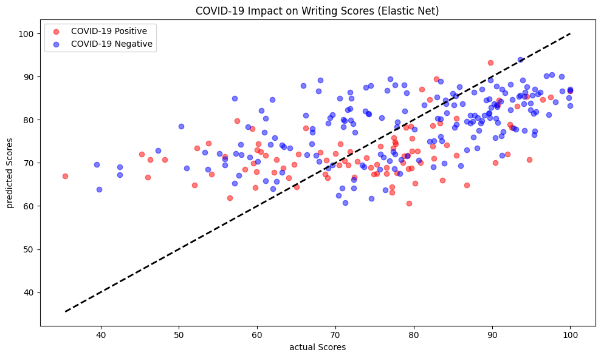

```python
covid_pos_writing = X_test_writing['covidpos'] == 1
covid_neg_writing = X_test_writing['covidpos'] == 0
plt.figure(figsize=(10, 6))
plt.scatter(y_test_writing[covid_pos_writing], y_pred_writing_en[covid_pos_writing], color='red', alpha=0.5, label='COVID-19 Positive')
plt.scatter(y_test_writing[covid_neg_writing], y_pred_writing_en[covid_neg_writing], color='blue', alpha=0.5, label='COVID-19 Negative')
plt.plot([y_test_writing.min(), y_test_writing.max()], [y_test_writing.min(), y_test_writing.max()], 'k--', lw=2)
plt.xlabel('actual Scores')
plt.ylabel('predicted Scores')
plt.title('COVID-19 Impact on Writing Scores (Elastic Net)')
plt.legend()
plt.tight_layout()
plt.show()
```

## Interpretation: Insight & Policy Decision

Based on what we've seen in our analysis and modeling, we can make a few key points:

**Subject Differences:** The performance of our models and the importance of features varied a bit between writing, reading, and math scores.

**Prediction Accuracy:** Our prediction accuracy wasn't as high as we'd hoped, which might be due to various reasons like data quality, the complexity of the problem, or the choice of models.

**COVID-19 Scatter Plots:** Our scatter plots showed the relationship between actual and predicted scores, highlighting the difference in predictions for COVID-19 positive and negative students. The model believes that those with covid generally score worse than those without covid.

**Policy Recommendations:** Given the importance of socioeconomic factors, schools and policymakers should focus on supporting students from lower-income backgrounds, especially during disruptions like pandemics. While addressing COVID-19's direct impacts is important, our analysis suggests a broader approach that considers multiple factors (like income, grade level, and gender) is necessary for effective academic support. Since feature importance varies by subject, interventions should be tailored to specific subjects instead of a one-size-fits-all approach.

Although our data didn't directly measure it, the strong influence of income suggests that ensuring all students have access to the necessary technology for remote learning could help reduce the academic impact of future pandemics.

**Future Research:** If we could conduct further research, we would:

1. Expand our dataset to include more detailed information about students' learning environments during the pandemic (e.g., access to technology, parental support, time spent in remote learning).
2. Incorporate qualitative data from interviews or surveys with students, teachers, and parents to gain deeper insights into how COVID-19 and other factors impact academic performance.
3. Explore more advanced machine learning techniques, such as neural networks or ensemble methods, to potentially improve our predictive accuracy.

We hope this analysis provides valuable insights into the complex factors affecting student performance during the COVID-19 pandemic. By leveraging these findings, educators and policymakers can develop more effective strategies to support students and mitigate the long-term effects of the pandemic on education.